# BDA_report

曹霞 黄雅雯 赵玉娇

2019/5/18

# 1 **团队成员简介**

## 1.1 **团队分工**

| STUDENT_NAME | STUDENT_NUMBER | WORK |
| --- | --- | --- |
| 曹霞 | 201643030 | 1. 搜集有关“幸福感”的背景资料，包含幸福悖论、宗教、性别认同、住房等相关方面的背景 2. 主笔报告团队概况部分 3. 整理GitHub相关学习资料并撰写Github工作报告 4. 可视化分析教育、地域、社会认知等方面变量与主观幸福感的关系 5. 建模分析(有序因变量回归分析、神经网络分析） |
| 黄雅雯 | 201638058 | 1. 搜集有关“幸福感”的背景资料，包含政策、世界幸福感排名等相关资料 2. 主笔数据预处理部分 3. 可视化宗教信仰、生活方式、家庭状况等方面变量与主观幸福感的关系 4. 建模分析(多元线性回归及主成分分析、二分变量回归分析) |
| 赵玉娇 | 201629019 | 1. 搜集有关“幸福感”的背景资料，包含政治、经济等方面的背景 2. 主笔数据来源以及问题背景部分 3. 可视化身心健康、工作就业等变量与主观幸福感的关系 4. 建模分析(泊松回归分析、决策树建模分析) |

## 1.2 **成员特长**

- 曹霞
  - 擅长于搜集资料与数据可视化，机器学习、数学、统计学等相关领域均有知识储备，具有较好的分析能力
- 黄雅雯
  - 擅长于数学与计算机科学，机器学习、统计学等相关领域均有知识储备，具有较好的实践能力
- 赵玉娇
  - 擅长于统计学与数学，机器学习、计算机科学等相关领域均有知识储备，具有较好的思维能力

团队知识结构如下图所示：

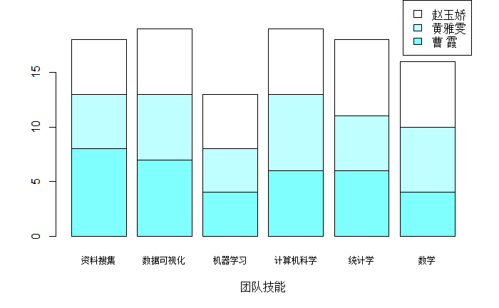

## 1.3 **协同方式**

- Github
- 实时讨论、及时沟通

# 2 **数据来源**

## 2.1 **下载来源**

数据下载来源为阿里云天池大数据竞赛新人赛，赛题为“快来一起挖掘幸福感！”下载地址：https://tianchi.aliyun.com/competition/entrance/231702/information (下载前需登陆报名)

## 2.2 **原始出处**

赛题所用数据的最初来源为中国人民大学中国调查与数据中心主持之《中国综合社会调查（CGSS）》项目2015年度的调查问卷，从中选取了多组变量，包括个体变量（性别、年龄、地域、职业、健康、婚姻与政治面貌等等）、家庭变量（父母、配偶、子女、家庭资本等等）、社会态度（公平、信用、公共服务等等）以及幸福感水平。  
中国综合社会调查（Chinese General Social Survey，CGSS），是中国第一个全国性、综合性、连续性的大型社会调查项目。目的是通过定期、系统地收集中国人与中国社会各个方面的数据，总结社会变迁的长期趋势，探讨具有重大理论和现实意义的社会议题，推动国内社会科学研究的开放性与共享性，为政府决策与国际比较研究提供数据资料。

# 3 **研究背景**

## 3.1 **历史背景**

> 国际上对幸福感的研究起始于二战后，从20世纪60年代逐步发展起来。Easterlin（1974，2010）最先研究了幸福与收入之间的关系，提出了“幸福悖论”，也称为“伊斯特林悖论”，即随着物质产品的丰富和收入水平的提升，人们并没有感觉更幸福，这类似一架“快乐水车”，尽管收入增长，但是幸福却没有同步增长。一个国家的主观幸福感随着经济发展上升到一定程度时，可能出现停滞或下降状态。随着时代的发展，“幸福悖论”也逐渐适用于中国。改革开放40年来，我国GDP持续高速增长，绝大多数居民的生活条件从根本上得到了改善，但是并无证据表明我国居民的幸福感呈现出与经济增长相匹配的提升。因此有必要对中国居民的幸福感进行研究。

> “户籍身份、社会分割与居民幸福感——基于不同影响机制的实证研究”

## 3.2 **政治背景**

> 党的十九大报告还特别强调了要把人民群众对美好生活的向往作为永远的奋斗目标，把人民的幸福快乐作为实现中国梦的重要标准，要让人们的幸福感、安全感、获得感更有保障、更充实、 更可持续。如何实现居民幸福感的提升，是各级政府进行社会治理工作需要关注的重要问题

> “中国居民的生活方式与主观幸福感研究 ———基于 CGSS2015 数据的实证分析”

## 3.3 **经济背景**

> “幸福感数据”被广泛应用于分析微观经济现象和对非市场商品的价值评估中（如健康状况、气候和噪音代价等），同时幸福感可能是经济结果的决定因素：它提高了生产力，预示了未来收入，影响了劳动力市场的表现。越来越多的幸福感研究表明，性格特征在理解幸福感和经济结果间联系方面起着重要作用。同时，相当数量的实证研究表明，幸福感更高的个体通常在工作中有更佳的表现，且在求职过程中也更为顺利

> [“经济学家为什么研究幸福感？”](https://mp.weixin.qq.com/s/8Uahhbi6AfRWz6w6WZxqIg)

## 3.4 **社会认知背景**

> Akerlof 和Kranton将身份定义为一种社会类别的归属感，同时考虑到该类别中的人应如何行事。例如，一种社会分类是按性别分类，性别身份认同不仅会对男女教育程度差异、性别工资差异产生影响，也会对家庭中家务劳动和家庭权利的分配产生影响，从而影响处于婚姻中个体的生活幸福感。

> “家庭内部相对收入、性别身份认同与中国居民生活幸福感——基于CGSS数据的实证研究”

> 信仰和价值观对于主观幸福感的影响是不容忽视的，弗洛伊德认为，宗教信仰对个体的思想和行为具有引导功能，宗教文化在精神上的保护功能有利于使得人类感知到幸福。

> “宗教信仰、社会支持与居民幸福感——基于CGSS2015数据的实证研究”

## 3.5 **现实背景**

> 据联合国发布的《世界幸福报告》显示,在156个受调查的国家中,2016-2018年中国的幸福感排名93，2010年起我国GDP总量已经超过日本, 成为仅次于美国的世界第二大经济体,但居民的幸福感排名却落后于大多数国家。

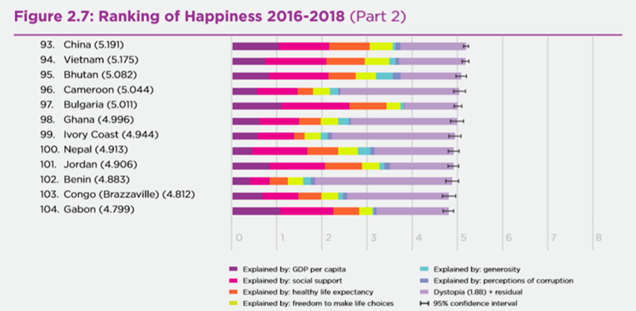

```r
image_path = "images/image_one.png"
rmarkdown::html_notebook_output_img(path = image_path, format = "png")
```

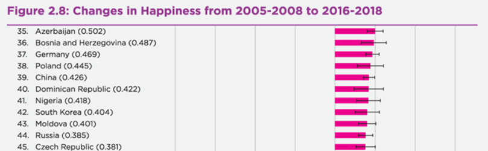

```r
image_path = "images/image_two.png"
rmarkdown::html_notebook_output_img(path = image_path, format = "png")
```

> 该报告中幸福感排名是基于对调查中提出的主要生活评估问题的回答。它要求受访者将自己当前的生活评定为0到10级，其中最好的可能生活是10级，最坏的可能生活是0级，这也叫做Cantril阶梯（Cantril Ladder）。此外，报告中统计了另外两个衡量幸福感的指标（积极影响、消极影响）和六个反应居民生活水平的变量。从报告中我们可以发现，中国的Ladder排名为93，Ladder的标准差排名为72，积极影响排名为21，消极影响排名为11，社会支持排名为108，自由程度排名为31，慷慨程度为133，人均GDP排名为68，预期寿命排名为34。

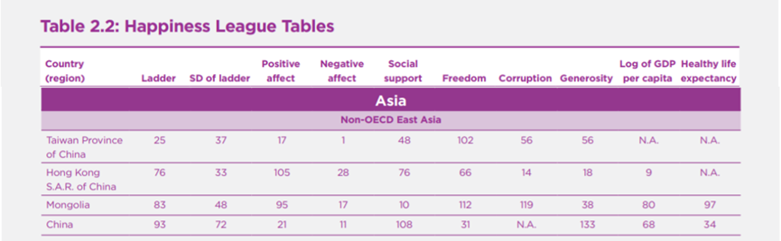

```r
image_path = "images/image_three.png"
rmarkdown::html_notebook_output_img(path = image_path, format = "png")
```

[《世界幸福报告》](https://s3.amazonaws.com/happiness-report/2019/WHR19.pdf)

# 4 **数据预处理**

## 4.1 **数据观测**

1. 读入数据

```r
library(tidyverse)
data_original<-read.csv("data/happiness_train_abbr.csv")
```

2. 简单观测data的头和尾

|  | id | happiness | survey_type | province | city | county | survey_time | gender | birth | nationality | religion | religion_freq | edu | income | political | floor_area | height_cm | weight_jin | health | health_problem | depression | hukou | socialize | relax | learn | equity | class | work_exper | work_status | … |
| --- | --- | --- | --- | --- | --- | --- | --- | --- | --- | --- | --- | --- | --- | --- | --- | --- | --- | --- | --- | --- | --- | --- | --- | --- | --- | --- | --- | --- | --- | --- |
| 1 | 1 | 4 | 1 | 12 | 32 | 59 | 2015/8/4 14:18 | 1 | 1959 | 1 | 1 | 1 | 11 | 20000 | 1 | 45 | 176 | 155 | 3 | 2 | 5 | 5 | 2 | 4 | 3 | 3 | 3 | 1 | 3 | … |
| 2 | 2 | 4 | 2 | 18 | 52 | 85 | 2015/7/21 15:04 | 1 | 1992 | 1 | 1 | 1 | 12 | 20000 | 1 | 110 | 170 | 110 | 5 | 4 | 3 | 1 | 2 | 4 | 3 | 3 | 6 | 1 | 3 | … |
| 3 | 3 | 4 | 2 | 29 | 83 | 126 | 2015/7/21 13:24 | 2 | 1967 | 1 | 0 | 3 | 4 | 2000 | 1 | 120 | 160 | 122 | 4 | 4 | 5 | 1 | 3 | 4 | 2 | 4 | 5 | 2 | NA | … |
| 4 | 4 | 5 | 2 | 10 | 28 | 51 | 2015/7/25 17:33 | 2 | 1943 | 1 | 1 | 1 | 3 | 6420 | 1 | 78 | 163 | 170 | 4 | 4 | 4 | 1 | 2 | 4 | 4 | 4 | 5 | 4 | NA | … |
| 5 | 5 | 4 | 1 | 7 | 18 | 36 | 2015/8/10 9:50 | 2 | 1994 | 1 | 1 | 1 | 12 | -1 | 2 | 70 | 165 | 110 | 5 | 5 | 3 | 2 | 4 | 3 | 4 | 2 | 1 | 6 | NA | … |
| 6 | 6 | 5 | 2 | 18 | 52 | 86 | 2015/7/18 12:09 | 1 | 1946 | 1 | 1 | 1 | 2 | 5000 | 1 | 300 | 172 | 140 | 5 | 5 | 4 | 1 | 3 | 3 | 2 | 4 | 8 | 4 | NA | … |

|  | id | happiness | survey_type | province | city | county | survey_time | gender | birth | nationality | religion | religion_freq | edu | income | political | floor_area | height_cm | weight_jin | health | health_problem | depression | hukou | socialize | relax | learn | equity | class | work_exper | work_status | … |
| --- | --- | --- | --- | --- | --- | --- | --- | --- | --- | --- | --- | --- | --- | --- | --- | --- | --- | --- | --- | --- | --- | --- | --- | --- | --- | --- | --- | --- | --- | --- |
| 7995 | 7995 | 4 | 1 | 15 | 39 | 70 | 2015/7/12 17:30 | 2 | 1975 | 1 | 1 | 1 | 4 | 0 | 1 | 300 | 158 | 130 | 4 | 3 | 3 | 1 | 4 | 4 | 2 | 3 | 4 | 3 | NA | … |
| 7996 | 7996 | 2 | 2 | 29 | 82 | 124 | 2015/7/21 19:36 | 1 | 1981 | 1 | 1 | 1 | 4 | 30000 | 1 | 260 | 176 | 150 | 5 | 4 | 3 | 1 | 4 | 4 | 4 | 3 | 5 | 4 | NA | … |
| 7997 | 7997 | 3 | 1 | 12 | 32 | 61 | 2015/7/31 16:00 | 2 | 1945 | 1 | 1 | 1 | 1 | 19200 | 1 | 320 | 152 | 90 | 3 | 3 | 3 | 1 | 4 | 4 | 1 | 4 | 3 | 4 | NA | … |
| 7998 | 7998 | 4 | 1 | 16 | 46 | 78 | 2015/8/1 17:48 | 2 | 1967 | 1 | 1 | 1 | 3 | 0 | 1 | 120 | 148 | 83 | 3 | 3 | 3 | 2 | 3 | 3 | 2 | 4 | 5 | 5 | NA | … |
| 7999 | 7999 | 3 | 1 | 1 | 1 | 8 | 2015/9/22 18:52 | 2 | 1978 | 1 | 1 | 1 | 12 | 170000 | 1 | 137 | 170 | 121 | 3 | 4 | 4 | 2 | 3 | 4 | 4 | 3 | 6 | 1 | 3 | … |
| 8000 | 8000 | 4 | 1 | 1 | 1 | 3 | 2015/9/28 20:22 | 2 | 1991 | 1 | 1 | 1 | 10 | 48000 | 1 | 58 | 160 | 120 | 4 | 5 | 5 | 5 | 3 | 4 | 2 | 4 | 6 | 1 | 4 | … |

3. 读入变量的含义

```r
data_index<-read.csv("data/happiness_index_1.csv")
data_index
```

| 变量名 | 问题 | 取值含义 |
| --- | --- | --- |
| - | 通用含义 | -1 = 不适用; -2 = 不知道; -3 = 拒绝回答; -8 = 无法回答; |
| id | 编号 | - |
| survey_type | 样本类型 | 1 = 城市; 2 = 农村; |
| province | 采访地点-省/自治区/直辖市编码 | 1 = 上海市; 2 = 云南省; 3 = 内蒙古自治区; 4 = 北京市; 5 = 吉林省; 6 = 四川省; 7 = 天津市; 8 = 宁夏回族自治区; 9 = 安徽省; 10 = 山东省; 11 = 山西省; 12 = 广东省; 13 = 广西壮族自治区; 14 = 新疆维吾尔自治区; 15 = 江苏省; 16 = 江西省; 17 = 河北省; 18 = 河南省; 19 = 浙江省; 20 … |
| city | 采访地点-地级市编码 | - |
| county | 采访地点-县/区编码 | - |
| survey_time | 问卷当前时间 | - |
| gender | 您的性别 | 1 = 男; 2 = 女; |
| birth | 您的出生日期-年 | - |
| nationality | 您的民族 | 1 = 汉; 2 = 蒙; 3 = 满; 4 = 回; 5 = 藏; 6 = 壮; 7 = 维; 8 = 其他; |

[output cut: 33 more lines]

4. 查看数据维度

```r
dim(data_original)
```

```
[1] 8000   42
```